# Evaluating Classification Model Performance

How the probability threshold changes a penguin sex classifier’s metrics

Author

Aniss Sahraoui

Published

September 13, 2026

# 1 Overview

A classification model rarely outputs a plain yes or no. It outputs a **probability**, and someone has to choose a **threshold** that turns the probability into a decision. This assignment evaluates a model that predicts whether a penguin is female. It looks at how the model’s errors, and the metrics built from them, change as the threshold moves from 0.2 to 0.5 to 0.8.

Throughout the analysis, **female is the positive class**: a *true positive* is a female penguin the model correctly calls female.

# 2 The Data

The predictions come from the course repository and are read directly from GitHub, so this document runs on any machine.

```r
penguins <- read_csv(
  "https://raw.githubusercontent.com/acatlin/data/master/penguin_predictions.csv",
  show_col_types = FALSE
)

glimpse(penguins)
```

```
Rows: 93
Columns: 3
$ .pred_female <dbl> 0.99217462, 0.95423945, 0.98473504, 0.18702056, 0.9947012…
$ .pred_class  <chr> "female", "female", "female", "male", "female", "female",…
$ sex          <chr> "female", "female", "female", "female", "female", "female…
```

There are 93 penguins and three columns:

| Column | Meaning |
| --- | --- |
| `.pred_female` | The model’s probability that the penguin is female |
| `.pred_class` | The model’s label at the default 0.5 threshold |
| `sex` | The penguin’s actual sex |

`.pred_class` holds the words `female` and `male` rather than the 1 and 0 described in the assignment. The check below confirms it is exactly the 0.5 rule applied to `.pred_female`, and that there are no missing values:

```r
tibble(
  missing_values           = sum(is.na(penguins)),
  pred_class_matches_rule  = all(penguins$.pred_class ==
                                   if_else(penguins$.pred_female > 0.5, "female", "male")),
  probs_exactly_at_a_threshold = sum(penguins$.pred_female %in% c(0.2, 0.5, 0.8))
)
```

| missing_values | pred_class_matches_rule | probs_exactly_at_a_threshold |
| --- | --- | --- |
| 0 | TRUE | 0 |

No probability sits exactly on 0.2, 0.5 or 0.8, so it makes no difference whether a threshold is applied with `>` or `>=`.

From here on, `.pred_class` is set aside. Every predicted class is recomputed from `.pred_female`, so that the threshold is under our control.

# 3 Null Error Rate

## 3.1 Class balance

```r
class_counts <- penguins |>
  count(sex) |>
  mutate(share = n / sum(n))

class_counts
```

| sex | n | share |
| --- | --- | --- |
| female | 39 | 0.4193548 |
| male | 54 | 0.5806452 |

```r
majority_class  <- class_counts |> slice_max(n) |> pull(sex)
null_accuracy   <- max(class_counts$share)
null_error_rate <- 1 - null_accuracy
```

The majority class is **male**. A “null model” that ignores every measurement and predicts male for every penguin is right 58.1% of the time. Its **null error rate is 41.9%**: the share of penguins that are not male.

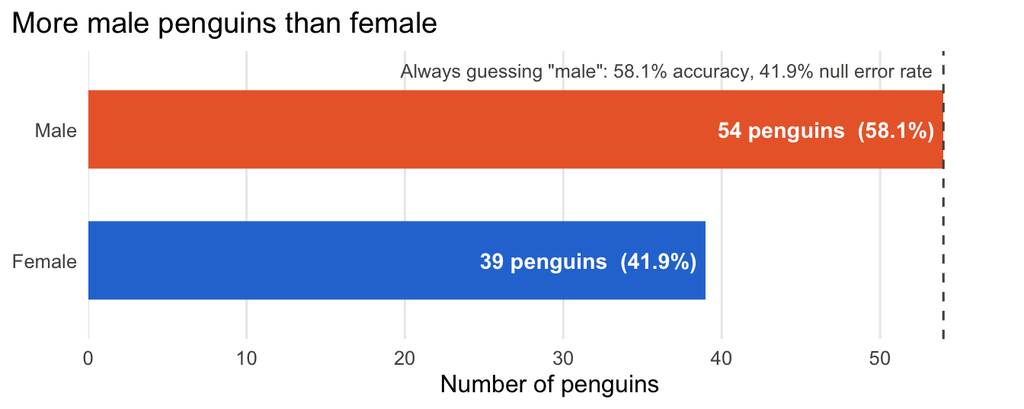

Figure 1: Actual sex of the penguins. The dashed line marks what a model that always guesses the majority class would score.

```r
class_counts |>
  mutate(sex = fct_reorder(str_to_title(sex), n),
         label = sprintf("%d penguins  (%s)", n, percent(share, 0.1))) |>
  ggplot(aes(x = n, y = sex, fill = sex)) +
  geom_col(width = 0.6) +
  geom_text(aes(label = label), hjust = 1.04, size = 3.8, color = "white", fontface = "bold") +
  geom_vline(xintercept = max(class_counts$n), linetype = "dashed", color = ink_2) +
  annotate("text", x = max(class_counts$n), y = 2.45, hjust = 1.02, size = 3.3, color = ink_2,
           label = sprintf("Always guessing \"%s\": %s accuracy, %s null error rate",
                           majority_class, percent(null_accuracy, 0.1),
                           percent(null_error_rate, 0.1))) +
  scale_fill_manual(values = c(Female = col_female, Male = col_male), guide = "none") +
  scale_x_continuous(expand = expansion(mult = c(0, 0.08))) +
  labs(title = "More male penguins than female",
       x = "Number of penguins", y = NULL) +
  theme_report +
  theme(panel.grid.major.y = element_blank())
```

## 3.2 Why the null error rate matters

Accuracy on its own has no reference point. A model that is “58.1% accurate” sounds respectable, yet on this data it has learned nothing: guessing male every time scores the same. The null error rate is the **floor**, the score a model must beat before it deserves credit.

The floor also moves with class balance. On data that is 95% one class, 95% accuracy is worthless. This is common in practice, for example with fraud, rare diseases or equipment failures, where the interesting class is small. Without the null error rate, a useless model can look excellent.

# 4 Seeing the Model’s Probabilities

Before building any confusion matrix, it helps to see where the probabilities fall. Each dot below is one penguin, placed by the model’s probability that it is female and grouped by its actual sex.

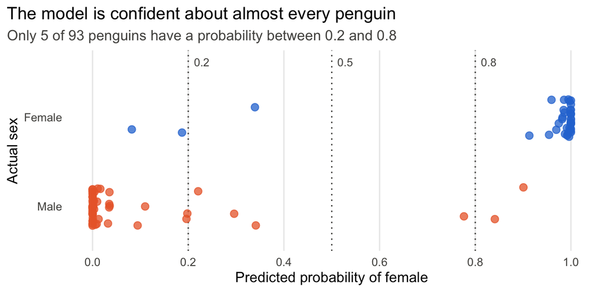

Figure 2: Predicted probability of female for every penguin, by actual sex. The dotted lines are the three thresholds.

```r
n_uncertain <- sum(penguins$.pred_female > 0.2 & penguins$.pred_female <= 0.8)

set.seed(607)
penguins |>
  mutate(sex = factor(str_to_title(sex), levels = c("Male", "Female"))) |>
  ggplot(aes(x = .pred_female, y = sex, color = sex)) +
  geom_vline(xintercept = c(0.2, 0.5, 0.8), linetype = "dotted", color = ink_2) +
  annotate("text", x = c(0.2, 0.5, 0.8) + 0.012, y = 2.62, hjust = 0,
           label = c("0.2", "0.5", "0.8"), size = 3.3, color = ink_2) +
  geom_jitter(height = 0.22, width = 0, size = 2.6, alpha = 0.75) +
  scale_color_manual(values = c(Female = col_female, Male = col_male), guide = "none") +
  scale_x_continuous(breaks = seq(0, 1, 0.2), limits = c(0, 1)) +
  scale_y_discrete(expand = expansion(add = c(0.5, 0.75))) +
  labs(title = "The model is confident about almost every penguin",
       subtitle = sprintf("Only %d of %d penguins have a probability between 0.2 and 0.8",
                          n_uncertain, nrow(penguins)),
       x = "Predicted probability of female", y = "Actual sex") +
  theme_report +
  theme(panel.grid.major.y = element_blank())
```

This plot explains everything that follows. Nearly every penguin sits near 0 or 1, so a threshold anywhere in the middle sorts them the same way. **Only 5 penguins can change sides as the threshold moves between 0.2 and 0.8**, so the differences between the three confusion matrices come down to a few birds.

# 5 Confusion Matrices at Three Thresholds

## 5.1 Computing TP, FP, TN and FN

At each threshold, a penguin is predicted female when `.pred_female > threshold`. It then falls into exactly one of four outcomes:

| Outcome | Predicted | Actual | Meaning |
| --- | --- | --- | --- |
| **TP** (true positive) | female | female | Female, correctly identified |
| **FP** (false positive) | female | male | Male, wrongly called female |
| **TN** (true negative) | male | male | Male, correctly identified |
| **FN** (false negative) | male | female | Female the model missed |

```r
thresholds <- c(0.2, 0.5, 0.8)

confusion_at <- function(threshold) {
  penguins |>
    mutate(predicted = if_else(.pred_female > threshold, "female", "male")) |>
    summarise(
      TP = sum(predicted == "female" & sex == "female"),
      FP = sum(predicted == "female" & sex == "male"),
      TN = sum(predicted == "male"   & sex == "male"),
      FN = sum(predicted == "male"   & sex == "female")
    ) |>
    mutate(threshold = threshold, .before = 1)
}

confusion <- map_dfr(thresholds, confusion_at)
confusion
```

| threshold | TP | FP | TN | FN |
| --- | --- | --- | --- | --- |
| 0.2 | 37 | 6 | 48 | 2 |
| 0.5 | 36 | 3 | 51 | 3 |
| 0.8 | 36 | 2 | 52 | 3 |

Every row adds up to 93. As a cross-check, base R’s `table()` gives the same counts at each threshold without any of the logic above:

```r
cross_check <- map_dfr(thresholds, \(t) {
  tab <- table(predicted = penguins$.pred_female > t, actual = penguins$sex)
  tibble(threshold = t,
         TP = tab["TRUE", "female"], FP = tab["TRUE", "male"],
         TN = tab["FALSE", "male"],  FN = tab["FALSE", "female"])
})

all.equal(as.data.frame(confusion), as.data.frame(cross_check))
```

```
[1] TRUE
```

## 5.2 The three matrices

```r
show_matrix <- function(threshold) {
  cm <- confusion |> filter(threshold == !!threshold)
  tibble(
    ` ` = c("**Predicted female**", "**Predicted male**"),
    `Actually female` = c(sprintf("TP = %d", cm$TP), sprintf("FN = %d", cm$FN)),
    `Actually male`   = c(sprintf("FP = %d", cm$FP), sprintf("TN = %d", cm$TN))
  ) |>
    kable(caption = sprintf("Threshold %.1f", threshold), align = "lcc") |>
    print()
  cat("\n\n")
}

walk(thresholds, show_matrix)
```

Threshold 0.2

|  | Actually female | Actually male |
| --- | --- | --- |
| **Predicted female** | TP = 37 | FP = 6 |
| **Predicted male** | FN = 2 | TN = 48 |

Threshold 0.5

|  | Actually female | Actually male |
| --- | --- | --- |
| **Predicted female** | TP = 36 | FP = 3 |
| **Predicted male** | FN = 3 | TN = 51 |

Threshold 0.8

|  | Actually female | Actually male |
| --- | --- | --- |
| **Predicted female** | TP = 36 | FP = 2 |
| **Predicted male** | FN = 3 | TN = 52 |

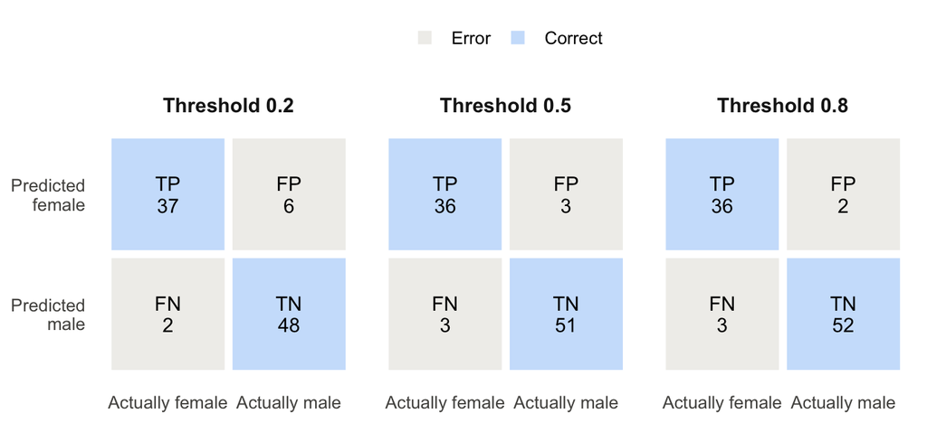

Figure 3: The same three confusion matrices. Correct predictions are on the diagonal.

```r
confusion |>
  pivot_longer(TP:FN, names_to = "outcome", values_to = "n") |>
  mutate(
    predicted = if_else(outcome %in% c("TP", "FP"), "Predicted\nfemale", "Predicted\nmale"),
    actual    = if_else(outcome %in% c("TP", "FN"), "Actually female", "Actually male"),
    correct   = outcome %in% c("TP", "TN"),
    threshold = sprintf("Threshold %.1f", threshold)
  ) |>
  ggplot(aes(x = actual, y = fct_rev(predicted))) +
  geom_tile(aes(fill = correct), color = "white", linewidth = 2) +
  geom_text(aes(label = sprintf("%s\n%d", outcome, n)), size = 3.8, lineheight = 0.9) +
  scale_fill_manual(values = c(`TRUE` = "#cde2fb", `FALSE` = "#f0efec"),
                    labels = c(`TRUE` = "Correct", `FALSE` = "Error"), name = NULL) +
  facet_wrap(~ threshold) +
  labs(x = NULL, y = NULL) +
  theme_report +
  theme(panel.grid = element_blank(), legend.position = "top",
        strip.text = element_text(face = "bold", size = 11))
```

Moving from 0.2 to 0.8, false positives fall from **6 to 2** and false negatives rise from **2 to 3**. That is the basic trade-off: a lower threshold calls more penguins female, catching more real females but also mislabeling more males. A higher threshold does the opposite.

# 6 Performance Metrics

Every metric is a different way of summarizing the four counts:

- **Accuracy** $= \dfrac{TP + TN}{\text{total}}$: the share of all penguins classified correctly.
- **Precision** $= \dfrac{TP}{TP + FP}$: of the penguins *called* female, the share that are female.
- **Recall** $= \dfrac{TP}{TP + FN}$: of the penguins that *are* female, the share the model found.
- **F1** $= 2 \cdot \dfrac{\text{precision} \cdot \text{recall}}{\text{precision} + \text{recall}}$: the harmonic mean of precision and recall. It is high only when both are.

```r
metrics <- confusion |>
  mutate(
    accuracy  = (TP + TN) / (TP + FP + TN + FN),
    precision = TP / (TP + FP),
    recall    = TP / (TP + FN),
    f1        = 2 * precision * recall / (precision + recall)
  )

metrics |>
  mutate(across(accuracy:f1, ~ sprintf("%.3f", .x))) |>
  rename(Threshold = threshold, Accuracy = accuracy, Precision = precision,
         Recall = recall, F1 = f1)
```

| Threshold | TP | FP | TN | FN | Accuracy | Precision | Recall | F1 |
| --- | --- | --- | --- | --- | --- | --- | --- | --- |
| 0.2 | 37 | 6 | 48 | 2 | 0.914 | 0.860 | 0.949 | 0.902 |
| 0.5 | 36 | 3 | 51 | 3 | 0.935 | 0.923 | 0.923 | 0.923 |
| 0.8 | 36 | 2 | 52 | 3 | 0.946 | 0.947 | 0.923 | 0.935 |

## 6.1 What the table shows

- **Every threshold clears the baseline comfortably.** Accuracy ranges from 91.4% to 94.6%, against 58.1% for always guessing male. The error rate falls from 41.9% to between 5.4% and 8.6%.
- **Precision and recall move in opposite directions.** Raising the threshold from 0.2 to 0.8 lifts precision from 0.860 to 0.947, while recall slips from 0.949 to 0.923.
- **At 0.5, precision and recall are equal** (0.923). That happens because the model makes exactly as many false positives as false negatives there (3 each).
- **0.8 scores best on accuracy and F1 here**, but the margins are tiny. The gap between 0.5 and 0.8 is a single penguin, and on 93 penguins one bird is worth about 1.1% of accuracy. These 93 penguins are too few to prove that 0.8 is better in general.

## 6.2 Beyond three thresholds

The assignment asks for three thresholds, but the same calculation runs just as easily at every threshold from 0.01 to 0.99. The curves show the trade-off from the table as a continuous picture.

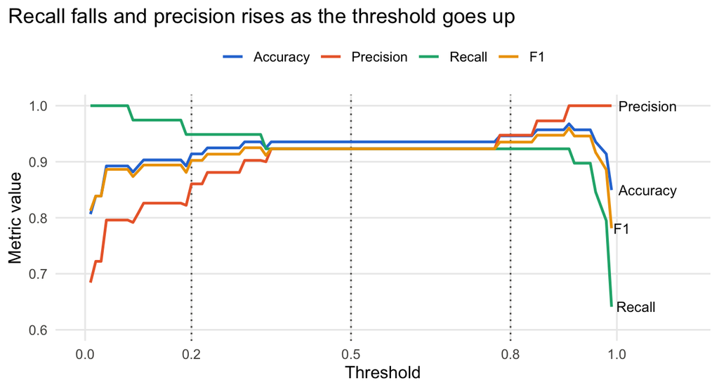

Figure 4: Metrics at every threshold from 0.01 to 0.99. The dotted lines mark 0.2, 0.5 and 0.8.

```r
sweep <- map_dfr(seq(0.01, 0.99, by = 0.01), confusion_at) |>
  mutate(Accuracy  = (TP + TN) / nrow(penguins),
         Precision = TP / (TP + FP),
         Recall    = TP / (TP + FN),
         F1        = 2 * Precision * Recall / (Precision + Recall)) |>
  pivot_longer(Accuracy:F1, names_to = "metric", values_to = "value") |>
  mutate(metric = factor(metric, levels = c("Accuracy", "Precision", "Recall", "F1")))

metric_colors <- c(Accuracy = "#2a78d6", Precision = "#eb6834", Recall = "#1baf7a", F1 = "#eda100")

end_labels <- sweep |> filter(threshold == 0.99)

ggplot(sweep, aes(x = threshold, y = value, color = metric)) +
  geom_vline(xintercept = thresholds, linetype = "dotted", color = ink_2) +
  geom_line(linewidth = 0.9) +
  geom_text(data = end_labels, aes(label = metric), hjust = -0.12, size = 3.5,
            color = "#0b0b0b") +
  scale_color_manual(values = metric_colors, name = NULL) +
  scale_x_continuous(breaks = c(0, 0.2, 0.5, 0.8, 1), limits = c(0, 1.12)) +
  scale_y_continuous(limits = c(0.6, 1), labels = number_format(accuracy = 0.1)) +
  labs(title = "Recall falls and precision rises as the threshold goes up",
       x = "Threshold", y = "Metric value") +
  theme_report +
  theme(legend.position = "top")
```

On this data, accuracy peaks at **96.8% with a threshold of 0.91**. It is tempting to adopt that threshold, but it would be tuned on the same penguins it is evaluated on, so it would look better here than on new penguins. A threshold should be chosen on separate validation data, and more importantly, by **what each kind of mistake costs**.

# 7 Choosing a Threshold: Use Cases

No threshold is best in general. The right one depends on which mistake is more expensive.

## 7.1 When a 0.2 threshold is preferable: missing a positive is costly

A low threshold flags a case as positive even when the model is only somewhat suspicious. It accepts more false positives to avoid false negatives, which suits situations where **missing a real positive is far worse than a false alarm**.

**Example: cancer screening.** A model reads mammograms and flags patients for a follow-up scan. A false positive means an extra appointment and a few anxious days. A false negative means a cancer goes undetected while it is still treatable. Flagging everyone with even a 20% estimated risk is the right call, because the follow-up scan catches the false alarms.

**The penguin version:** a conservation team relocating female penguins to a protected breeding site. Missing a female weakens the new colony, while a male included by mistake can be sorted out with a quick field check. A 0.2 threshold gathers nearly every female: recall is 0.949, and only 2 females are missed.

## 7.2 When a 0.8 threshold is preferable: a false alarm is costly

A high threshold acts only when the model is confident. It accepts missing some positives in return for fewer false positives, which suits situations where **acting on a wrong prediction is expensive, harmful or hard to undo**.

**Example: automatically blocking a credit card for fraud.** A false positive freezes a genuine customer’s card at a checkout, which costs goodwill and sometimes the customer. A missed fraudulent charge can still be caught by later review. Blocking automatically only above 0.8, and sending lower-confidence cases to a human reviewer, keeps false alarms rare.

**The penguin version:** a study that fits only female penguins with a harness-mounted tracker sized for females. Fitting one to a larger male could injure it, and the capture itself stresses the bird. At 0.8, precision is 0.947 and only 2 males would be caught by mistake.

# 8 Findings

- **The baseline is 41.9% error.** Always guessing male gets that far, and the model beats it at all three thresholds.
- **The model is confident.** Only 5 of 93 penguins have a probability between 0.2 and 0.8, so the three thresholds differ by just a few penguins.
- **The threshold trades one error for another.** From 0.2 to 0.8, false positives fall from 6 to 2 while false negatives rise from 2 to
  3. Precision rises and recall falls.
- **0.8 scored highest on accuracy and F1, by one or two penguins.** That is too small a difference to call a real advantage. The choice should follow the cost of each mistake, as in the use cases above, and be tested on new data.

# 9 References

- [Performance Metrics for Classification Problems in Machine Learning](https://github.com/acatlin/data/blob/master/Performance%20Metrics%20for%20Classification%20problems%20in%20Machine%20Learning.pdf) (course reading, from the DATA 607 course repository).
- Course data: [`penguin_predictions.csv`](https://github.com/acatlin/data/blob/master/penguin_predictions.csv).
- Claude AI (Anthropic) and ChatGPT (OpenAI) were used for assistance. I reviewed, ran and verified all code myself.